# Section 2: Linear Model Review

Pablo Arés Gastesi

2026-07-06

# 1 Introduction

You have already studied linear regression in earlier courses. This note is not a full re-introduction — it is a review with an ML perspective: we emphasise prediction rather than inference, and we set up the language and tools that will be used throughout the rest of the course.

When computing a linear model, or any Machine Learning model, two important questions come up:

1. How well does the model fit the data it was trained on? (training error)
2. How well does it predict new, unseen data? (test error)

These two are not the same, and the gap between them is the central problem of machine learning. We return to it properly in the Cross-Validation notes (Section 4).

We work throughout with the `Auto` dataset from the `ISLR2` package: fuel consumption (`mpg`) of 392 cars, together with engine and performance variables. For further reading, [ISLR2 Chapters 2–3](https://www.statlearning.com/) cover this material in detail.

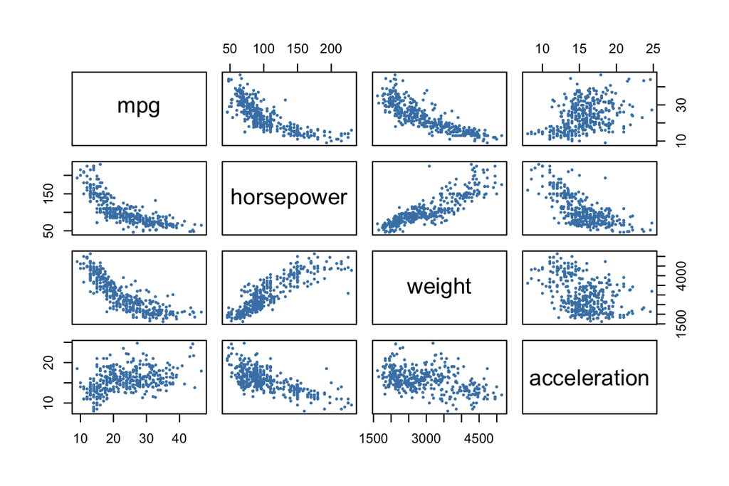

Figure 1.1: Pairwise scatter plots of selected variables in the Auto dataset

```r
data(Auto)
Auto %>%
  select(mpg, horsepower, weight, acceleration) %>%
  pairs(col = "steelblue", pch = 16, cex = 0.5)
```

# 2 Simple linear regression

## 2.1 The model

Simple linear regression models a numeric response $Y$ as a linear function of a single predictor $X$:

$$Y = \beta_0 + \beta_1 X + \varepsilon$$

where $\varepsilon$ is a zero-mean error term capturing everything the model misses. The parameters $\beta_0$ (intercept) and $\beta_1$ (slope) are estimated by minimising the **Residual Sum of Squares (RSS)**:

$$\text{RSS} = \sum_{i=1}^{n}(y_i - \widehat y_i)^2 = \sum_{i=1}^{n}(y_i - \widehat\beta_0 - \widehat\beta_1 x_i)^2$$

This is the ordinary least squares (OLS) estimator, which has a closed-form solution: $\widehat\beta_1 = \text{Cov}(X,Y)/\text{Var}(X)$ and $\widehat\beta_0 = \bar y - \widehat\beta_1 \bar x$. Remember from the *Introduction to Machine Learning* section that the coefficients, though given by a closed formula, are **learned** from the data, and that makes the linear model part of Machine Learning. What we get are estimates on the parameters $\beta_0$ and $\beta_1$. Training on a different set will produce different parameters.

We write
$$\widehat{Y} = \widehat{\beta_0} + \widehat{\beta_1} X$$
for the model obtained from the training data.

## 2.2 Fitting in R

The function used for the linear model in `R`, in one or several variables, is `lm`. The `summary` function gives us the details of the model.

```r
fit_slr <- lm(mpg ~ horsepower, data = Auto)
summary(fit_slr)
```

```
##
## Call:
## lm(formula = mpg ~ horsepower, data = Auto)
##
## Residuals:
##      Min       1Q   Median       3Q      Max
## -13.5710  -3.2592  -0.3435   2.7630  16.9240
##
## Coefficients:
##              Estimate Std. Error t value Pr(>|t|)
## (Intercept) 39.935861   0.717499   55.66   <2e-16 ***
## horsepower  -0.157845   0.006446  -24.49   <2e-16 ***
## ---
## Signif. codes:  0 '***' 0.001 '**' 0.01 '*' 0.05 '.' 0.1 ' ' 1
##
## Residual standard error: 4.906 on 390 degrees of freedom
## Multiple R-squared:  0.6059, Adjusted R-squared:  0.6049
## F-statistic: 599.7 on 1 and 390 DF,  p-value: < 2.2e-16
```

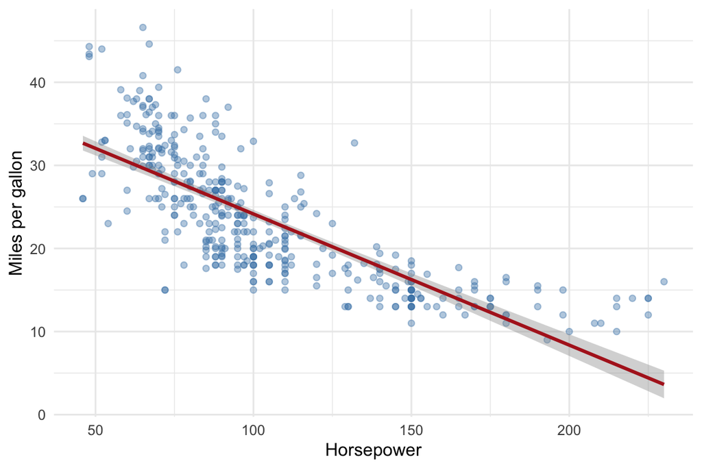

Figure 2.1: Simple linear regression of mpg on horsepower

```r
ggplot(Auto, aes(x = horsepower, y = mpg)) +
  geom_point(alpha = 0.4, colour = "steelblue") +
  geom_smooth(method = "lm", se = TRUE, colour = "firebrick", linewidth = 1) +
  labs(x = "Horsepower", y = "Miles per gallon") +
  theme_minimal()
```

## 2.3 Interpreting the output

We can use the function `predict` to get estimates for new data. Below you can see the prediction for four new points, along with the prediction interval, that takes into account the irreducible error. Remember that the data frame given in the option `newdata` should have columns with the names of the predictors equal to the names given in the `lm` function.

```r
new_cars <- data.frame(horsepower = c(80, 120, 160, 200))
preds    <- predict(fit_slr, newdata = new_cars, interval = "prediction")
cbind(new_cars, round(preds, 2))
```

|  | horsepower | fit | lwr | upr |
| --- | --- | --- | --- | --- |
| 1 | 80 | 27.31 | 17.65 | 36.97 |
| 2 | 120 | 20.99 | 11.34 | 30.65 |
| 3 | 160 | 14.68 | 5.00 | 24.36 |
| 4 | 200 | 8.37 | -1.37 | 18.10 |

`interval = "prediction"` gives a 95% interval for an *individual* new observation, which is wider than a confidence interval for the mean response.

# 3 Residual analysis

Residuals $e_i = y_i - \widehat y_i$, the “mistakes” made by the model, should be random: no pattern against fitted values, no trend over time, approximately normal. Systematic patterns signal that the model is mis-specified.

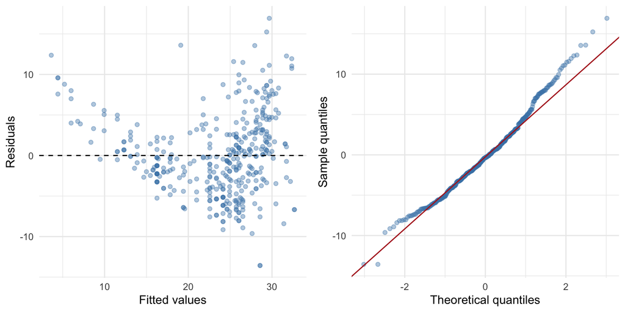

Figure 3.1: Residual plots for the simple linear model

```r
auto_aug <- Auto %>%
  mutate(fitted   = fitted(fit_slr),
         residual = residuals(fit_slr))

p1 <- ggplot(auto_aug, aes(x = fitted, y = residual)) +
  geom_point(alpha = 0.4, colour = "steelblue") +
  geom_hline(yintercept = 0, linetype = "dashed") +
  labs(x = "Fitted values", y = "Residuals") +
  theme_minimal()

p2 <- ggplot(auto_aug, aes(sample = residual)) +
  stat_qq(alpha = 0.4, colour = "steelblue") +
  stat_qq_line(colour = "firebrick") +
  labs(x = "Theoretical quantiles", y = "Sample quantiles") +
  theme_minimal()

gridExtra::grid.arrange(p1, p2, ncol = 2)
```

The left plot shows a clear curved pattern: residuals are positive at the extremes and negative in the middle. This tells us the true relationship is not linear. The Q-Q plot also shows departures from normality in the tails. Both are signals that we need a richer model.

# 4 Multiple linear regression

## 4.1 The model

With $p$ predictors:

$$Y = \beta_0 + \beta_1 X_1 + \cdots + \beta_p X_p + \varepsilon$$

Each $\beta_j$ is the expected change in $Y$ per unit increase in $X_j$, holding all other predictors fixed. This is the key difference from running $p$ separate simple regressions.

```r
fit_mlr <- lm(mpg ~ horsepower + weight + acceleration + year, data = Auto)
summary(fit_mlr)
```

```
##
## Call:
## lm(formula = mpg ~ horsepower + weight + acceleration + year,
##     data = Auto)
##
## Residuals:
##     Min      1Q  Median      3Q     Max
## -8.6693 -2.3618 -0.0982  2.0105 14.2926
##
## Coefficients:
##                Estimate Std. Error t value Pr(>|t|)
## (Intercept)  -1.539e+01  4.671e+00  -3.294  0.00108 **
## horsepower    2.622e-03  1.339e-02   0.196  0.84483
## weight       -6.634e-03  4.706e-04 -14.099  < 2e-16 ***
## acceleration  8.022e-02  9.986e-02   0.803  0.42228
## year          7.511e-01  5.223e-02  14.381  < 2e-16 ***
## ---
## Signif. codes:  0 '***' 0.001 '**' 0.01 '*' 0.05 '.' 0.1 ' ' 1
##
## Residual standard error: 3.432 on 387 degrees of freedom
## Multiple R-squared:  0.8086, Adjusted R-squared:  0.8067
## F-statistic: 408.8 on 4 and 387 DF,  p-value: < 2.2e-16
```

$R^2$ has increased to 0.809: adding `weight`, `acceleration`, and `year` explains considerably more of the variance in `mpg`.

## 4.2 Comparing models

The F-statistic tests whether any predictor is useful (H₀: all slopes are zero). For individual predictors, the t-statistics and p-values work as in simple regression.

**Caution:** $R^2$ always increases when you add more predictors, even useless ones. Adjusted $R^2$ penalises for the number of predictors and is a fairer comparison:

$$\bar R^2 = 1 - \frac{\text{RSS}/(n-p-1)}{\text{TSS}/(n-1)}$$

```r
data.frame(
  Model       = c("One predictor (horsepower)", "Four predictors"),
  R2          = c(summary(fit_slr)$r.squared, summary(fit_mlr)$r.squared),
  Adj_R2      = c(summary(fit_slr)$adj.r.squared, summary(fit_mlr)$adj.r.squared),
  RSE         = c(summary(fit_slr)$sigma, summary(fit_mlr)$sigma)
) %>% mutate(across(where(is.numeric), ~ round(.x, 4)))
```

| Model | R2 | Adj_R2 | RSE |
| --- | --- | --- | --- |
| One predictor (horsepower) | 0.6059 | 0.6049 | 4.9058 |
| Four predictors | 0.8086 | 0.8067 | 3.4319 |

# 5 Qualitative predictors

## 5.1 Dummy variables

So far all predictors have been numeric. What if a predictor is categorical — for example, the origin of a car (American, European, Japanese)?

We cannot feed text into a regression formula. Instead, R encodes a factor with $k$ levels using $k - 1$ dummy variables (also called indicator variables). One level is left out as the reference category; its effect is absorbed into the intercept. This avoids perfect collinearity: if we created a dummy for every level, the $k$ dummies would sum to 1 and be perfectly collinear with the intercept.

For a factor with three levels — say, American (reference), European, Japanese — two dummies are created:

$$X_{\text{European}} = \begin{cases} 1 & \text{if European} \\ 0 & \text{otherwise} \end{cases}
\qquad
X_{\text{Japanese}} = \begin{cases} 1 & \text{if Japanese} \\ 0 & \text{otherwise} \end{cases}$$

The model becomes:

$$Y = \beta_0 + \beta_1 X_{\text{European}} + \beta_2 X_{\text{Japanese}} + \varepsilon$$

Plugging in the three cases:

- American car: $\widehat Y = \beta_0$
- European car: $\widehat Y = \beta_0 + \beta_1$
- Japanese car: $\widehat Y = \beta_0 + \beta_2$

The intercept is the mean response for the reference category, and each dummy coefficient is the difference in mean response relative to the reference, holding all other predictors fixed.

## 5.2 Example: origin in the Auto dataset

The `origin` variable is stored as an integer (1 = American, 2 = European, 3 = Japanese). We must convert it to a factor before passing it to `lm`; otherwise R will treat it as a numeric predictor and fit a single slope across all three values.

```r
Auto <- Auto %>%
  mutate(origin_f = factor(origin, levels = 1:3,
                           labels = c("American", "European", "Japanese")))

fit_origin <- lm(mpg ~ horsepower + weight + origin_f, data = Auto)
summary(fit_origin)
```

```
##
## Call:
## lm(formula = mpg ~ horsepower + weight + origin_f, data = Auto)
##
## Residuals:
##      Min       1Q   Median       3Q      Max
## -12.3772  -2.9241  -0.3991   2.2345  14.8164
##
## Coefficients:
##                    Estimate Std. Error t value Pr(>|t|)
## (Intercept)      42.7399583  1.1011112  38.815  < 2e-16 ***
## horsepower       -0.0535442  0.0109835  -4.875 1.59e-06 ***
## weight           -0.0048427  0.0005455  -8.878  < 2e-16 ***
## origin_fEuropean  0.9611172  0.6402552   1.501    0.134
## origin_fJapanese  2.7422385  0.6517055   4.208 3.21e-05 ***
## ---
## Signif. codes:  0 '***' 0.001 '**' 0.01 '*' 0.05 '.' 0.1 ' ' 1
##
## Residual standard error: 4.157 on 387 degrees of freedom
## Multiple R-squared:  0.7193, Adjusted R-squared:  0.7164
## F-statistic: 247.9 on 4 and 387 DF,  p-value: < 2.2e-16
```

R automatically uses the first factor level (American) as the reference. The coefficients `origin_fEuropean` and `origin_fJapanese` tell us how much more (or less) fuel-efficient European and Japanese cars are on average, after controlling for horsepower and weight.

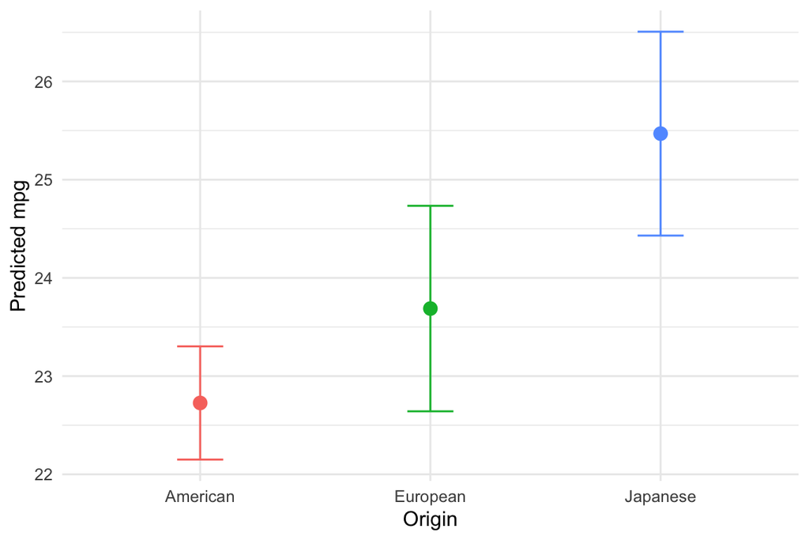

Figure 5.1: Predicted mpg by origin, at the mean horsepower and weight

```r
# Predicted mpg at mean horsepower and weight for each origin
new_origin <- data.frame(
  horsepower = mean(Auto$horsepower),
  weight     = mean(Auto$weight),
  origin_f   = factor(c("American", "European", "Japanese"),
                      levels = c("American", "European", "Japanese"))
)

pred_origin <- cbind(new_origin,
                     predict(fit_origin, newdata = new_origin,
                             interval = "confidence"))

ggplot(pred_origin, aes(x = origin_f, y = fit, colour = origin_f)) +
  geom_point(size = 3) +
  geom_errorbar(aes(ymin = lwr, ymax = upr), width = 0.2) +
  labs(x = "Origin", y = "Predicted mpg", colour = NULL) +
  theme_minimal() +
  theme(legend.position = "none")
```

The plot shows the model’s predicted mpg for a car of average horsepower and weight, by origin, with 95% confidence intervals for the mean response.

# 6 Polynomial regression

The residual plot above showed a curved relationship between `mpg` and `horsepower`. One natural fix is to include polynomial terms. For degree $d$:

$$Y = \beta_0 + \beta_1 X + \beta_2 X^2 + \cdots + \beta_d X^d + \varepsilon$$

This is still a *linear* model — linear in the coefficients $\beta_j$ — so `lm()` handles it directly via `poly()`.

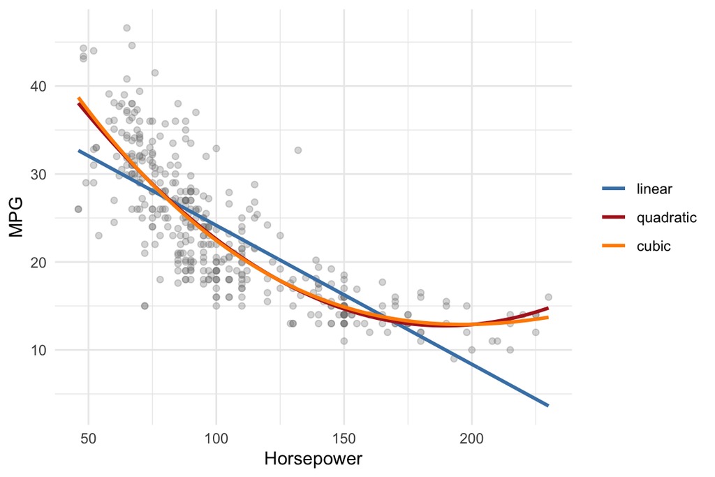

Figure 6.1: Polynomial fits of degree 1, 2, and 3 for mpg on horsepower

```r
fits <- list(
  linear    = lm(mpg ~ poly(horsepower, 1), data = Auto),
  quadratic = lm(mpg ~ poly(horsepower, 2), data = Auto),
  cubic     = lm(mpg ~ poly(horsepower, 3), data = Auto)
)

hp_grid <- data.frame(horsepower = seq(min(Auto$horsepower),
                                       max(Auto$horsepower),
                                       length.out = 300))

preds_poly <- hp_grid %>%
  mutate(
    linear    = predict(fits$linear,    newdata = hp_grid),
    quadratic = predict(fits$quadratic, newdata = hp_grid),
    cubic     = predict(fits$cubic,     newdata = hp_grid)
  ) %>%
  pivot_longer(-horsepower, names_to = "model", values_to = "mpg") %>%
  mutate(model = factor(model, levels = c("linear", "quadratic", "cubic")))

ggplot(Auto, aes(x = horsepower, y = mpg)) +
  geom_point(alpha = 0.3, colour = "grey50") +
  geom_line(data = preds_poly, aes(colour = model), linewidth = 1) +
  scale_colour_manual(values = c(linear    = "steelblue",
                                 quadratic = "firebrick",
                                 cubic     = "darkorange")) +
  labs(x = "Horsepower", y = "MPG", colour = NULL) +
  theme_minimal()
```

```r
data.frame(
  Degree  = 1:3,
  R2      = sapply(fits, function(f) round(summary(f)$r.squared, 4)),
  Adj_R2  = sapply(fits, function(f) round(summary(f)$adj.r.squared, 4)),
  RSE     = sapply(fits, function(f) round(summary(f)$sigma, 4))
)
```

|  | Degree | R2 | Adj_R2 | RSE |
| --- | --- | --- | --- | --- |
| linear | 1 | 0.6059 | 0.6049 | 4.9058 |
| quadratic | 2 | 0.6876 | 0.6860 | 4.3739 |
| cubic | 3 | 0.6882 | 0.6858 | 4.3750 |

# 7 Training error vs. test error

Everything computed so far — $R^2$, RSE, residuals — measures how well the model fits the **training data**: the same observations used to estimate the coefficients.

This is *not* a reliable measure of prediction quality on new data. Consider what happens if we keep adding polynomial terms:

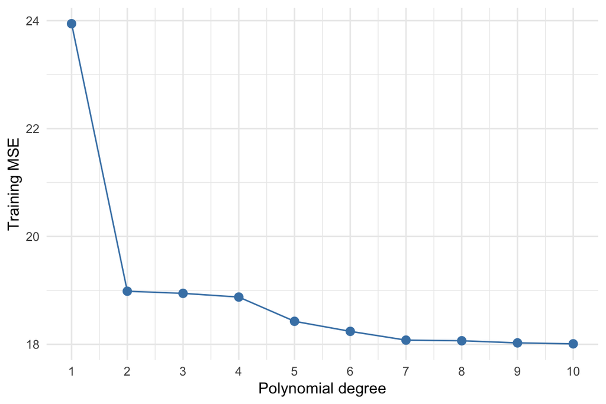

Figure 7.1: Training MSE decreases as degree increases, but the model may be overfitting

```r
mse_train <- sapply(1:10, function(d) {
  f <- lm(mpg ~ poly(horsepower, d), data = Auto)
  mean(residuals(f)^2)
})

ggplot(data.frame(degree = 1:10, MSE = mse_train), aes(x = degree, y = MSE)) +
  geom_line(colour = "steelblue") +
  geom_point(colour = "steelblue", size = 2.5) +
  scale_x_continuous(breaks = 1:10) +
  labs(x = "Polynomial degree", y = "Training MSE") +
  theme_minimal()
```

Training MSE decreases monotonically as we add more terms: a more complex model always fits the training data better. But **a model that fits the training data too closely may perform poorly on new data** — it has memorised noise rather than learned the underlying pattern. This is **overfitting**.

The right question is: what is the **test MSE** — the error on observations the model has never seen? To answer it, we need **Cross-Validation** (topic 04).

> **Key message:** never judge a model’s predictive ability using the same data that was used to fit it.

# 8 The MSE as a loss function

Throughout this course we quantify prediction error with the **Mean Squared Error**:

$$\text{MSE} = \frac{1}{n} \sum_{i=1}^{n} (y_i - \hat y_i)^2$$

Its square root, the **RMSE**, is in the same units as $Y$ and easier to interpret.

The MSE has a useful decomposition at any point $x_0$:

$$E\left[(y_0 - \hat f(x_0))^2\right] = \underbrace{\text{Var}(\hat f(x_0))}_{\text{variance}} + \underbrace{[\text{Bias}(\hat f(x_0))]^2}_{\text{bias}^2} + \underbrace{\text{Var}(\varepsilon)}_{\text{irreducible error}}$$

- **Variance**: how much the fitted model changes if we re-train on a different sample. Complex models have high variance.
- **Bias**: how far the model’s average prediction is from the truth. Simple models (e.g., a straight line fitting a curved relationship) have high bias.
- **Irreducible error**: noise in the data that no model can remove.

This **bias–variance trade-off** is a central theme of machine learning: reducing one typically increases the other. The goal is to find the right complexity for the problem at hand.

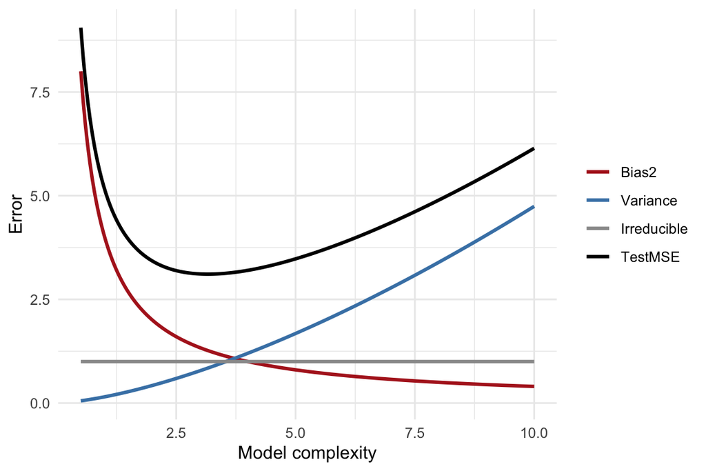

Figure 8.1: Schematic of the bias-variance trade-off

```r
complexity <- seq(0.5, 10, length.out = 200)
bv_df <- data.frame(
  complexity = complexity,
  Bias2      = 4 / complexity,
  Variance   = 0.15 * complexity^1.5,
  Irreducible = rep(1, 200)
) %>%
  mutate(TestMSE = Bias2 + Variance + Irreducible) %>%
  pivot_longer(-complexity, names_to = "component", values_to = "value") %>%
  mutate(component = factor(component,
    levels = c("Bias2", "Variance", "Irreducible", "TestMSE")))

ggplot(bv_df, aes(x = complexity, y = value, colour = component)) +
  geom_line(linewidth = 1) +
  scale_colour_manual(values = c(Bias2       = "firebrick",
                                 Variance    = "steelblue",
                                 Irreducible = "grey60",
                                 TestMSE     = "black")) +
  labs(x = "Model complexity", y = "Error", colour = NULL) +
  theme_minimal()
```

The test MSE (black) has a U-shape: too simple means high bias, too complex means high variance. The sweet spot is in the middle. Finding it is what cross-validation is for.

# 9 What if the response is categorical?

Everything above assumes $Y$ is numeric. What if we want to predict whether a student is admitted, whether a transaction is fraudulent, or whether a tumour is malignant?

Trying to use a linear model directly on a 0/1 coded response causes problems: predictions go outside $[0,1]$ and are not interpretable as probabilities.

We need a different model — one that outputs probabilities and is then turned into a class prediction. That is **logistic regression**, the topic of note 03.

# 10 Summary

| Concept | Formula / function | Notes |
| --- | --- | --- |
| Simple linear regression | `lm(y ~ x)` | one predictor |
| Multiple linear regression | `lm(y ~ x1 + x2 + ...)` | several predictors |
| Polynomial regression | `lm(y ~ poly(x, d))` | still linear in coefficients |
| $R^2$ | `summary(fit)$r.squared` | fraction of variance explained |
| RSE | `summary(fit)$sigma` | typical residual size |
| Predictions | `predict(fit, newdata, interval)` | with or without intervals |
| Training MSE | `mean(residuals(fit)^2)` | not reliable for model selection |
| Qualitative predictor | `factor(x)` then `lm(y ~ x)` | R creates $k-1$ dummies; coefficients are differences vs. reference level |